# [번역]폴더안의 csv 파일들을 {purrr}와 {readr}을 이용해서 한방에 불러오기

R

purrr

readr

csv

read

{purrr}의 `map_dfr()` 함수로 폴더내의 파일 리스트를 한번에 불러올 수 있습니다.

true  
2018-10-27

> 본 번역은 [원글](https://www.gerkelab.com/blog/2018/09/import-directory-csv-purrr-readr/)을 대상으로 [CC-BY](https://creativecommons.org/licenses/by/4.0/) 라이선스를 사용하고 있어 마음껏 번역하였습니다.  
> 요약 : {purrr}의 `map_dfr()` 함수로 폴더내의 파일 리스트를 한번에 불러올 수 있다.

이번 포스트는 `tidyverse` 패키지에 속한 두 패키지(`purrr`&`readr`)를 사용해서 csv 파일 리스트를 하나의 data.frame으로 불러오는 방법을 설명합니다. 또한 `fs`라는 새로운 파일 시스템 대응 패키지를 사용합니다.

```r
# 필요한 패키지를 설치합니다.
# install.packages(c("tidyverse", "fs"))

library(tidyverse)  # purrr와 readr을 불러옵니다.
library(fs)
```

### 문제 상황 설정

규칙적인 데이터를 포함하는 CSV 파일들이 한 디렉토리에 있다고 가정합니다. 즉, 각 데이터 세트의 열이 모두 동일하거나 적어도 중복되는 열이 동일하다는 것을 의미한다고 가정합니다.

우리는 디렉토리 안의 모든 CSV 파일을 읽어서 각각의 파일을 불러온 작은 데이터셋을 합쳐 하나의 큰 데이터셋으로 만들고 싶습니다.

### 예제 데이터

예를 좀 더 구체적으로 설명하기 위해 [아일랜드 정부가 제공한 데이터셋](https://data.gov.ie/dataset/general-referrals-by-hospital-department-and-year)을 사용하겠습니다. 이 데이터셋은 병원 부서별 연간 온라인 추천수로, 각 년도별로 파일이 구분되어 있습니다.

데이터는 [data.gov.ie](https://data.gov.ie/dataset/general-referrals-by-hospital-department-and-year)에서 개별 csv 파일들을 다운로드 받거나, 미리 준비한 [압축 파일](https://www.gerkelab.com/data/ie-general-referrals-by-hospital.zip)을 다운 받을 수 있습니다.

한 폴더 내에 csv 파일들을 다운로드 받았거나, 압축 파일을 풀어놓은 후에 `data_dir` 객체에 경로를 지정합니다.

```r
data_dir <- "ie-general-referrals-by-hospital"
```

`fs::dir_ls()` 함수를 사용해서 폴더내의 파일 리스트를 가져올 수 있습니다.

```r
fs::dir_ls(data_dir)
```

```
ie-general-referrals-by-hospital/README.txt
ie-general-referrals-by-hospital/general-referrals-by-hospital-department-2015.csv
ie-general-referrals-by-hospital/general-referrals-by-hospital-department-2016.csv
ie-general-referrals-by-hospital/general-referrals-by-hospital-department-2017.csv
ie-general-referrals-by-hospital/general-referrals-by-hospital-department-2018.csv
```

리스트를 보니 `README.txt` 파일이 추가로 있습니다. 이 파일은 우리가 불러오고자 하는 파일이 아닙니다. 그렇기 때문에 폴더 내의 파일 리스트를 불러올 때 csv 파일 형식으로만 제한할 필요가 있습니다. 파일명이 `.csv`로 끝나는 것들만 조건을 주면 좋겠습니다.

```r
csv_files <- fs::dir_ls(data_dir, regexp = "\\.csv$")
csv_files
```

```
ie-general-referrals-by-hospital/general-referrals-by-hospital-department-2015.csv
ie-general-referrals-by-hospital/general-referrals-by-hospital-department-2016.csv
ie-general-referrals-by-hospital/general-referrals-by-hospital-department-2017.csv
ie-general-referrals-by-hospital/general-referrals-by-hospital-department-2018.csv
```

### 파일 전체를 불러오기

#### 우선 한 파일을 불러오기

각 csv 파일들을 `readr::read_csv()` 함수를 이용해서 각각 불러올 수 있습니다. 한 파일만 먼저 예시로 불러와 보겠습니다.

```r
readr::read_csv(csv_files[1])
```

```
# A tibble: 837 x 6
   Month_Year Hospital_Name Hospital_ID Hospital_Depart… ReferralType
   <chr>      <chr>               <dbl> <chr>            <chr>
 1 Aug-15     AMNCH                1049 Paediatric ENT   General Ref…
 2 Aug-15     AMNCH                1049 Paediatric Gast… General Ref…
 3 Aug-15     AMNCH                1049 Paediatric Gene… General Ref…
 4 Aug-15     Bantry Gener…         704 Gastroenterology General Ref…
 5 Aug-15     Bantry Gener…         704 General Medicine General Ref…
 6 Aug-15     Bantry Gener…         704 General Surgery  General Ref…
 7 Aug-15     Bantry Gener…         704 Medicine for th… General Ref…
 8 Aug-15     Bantry Gener…         704 Outreach Dermat… General Ref…
 9 Aug-15     Bantry Gener…         704 Outreach Orthop… General Ref…
10 Aug-15     Bantry Gener…         704 Outreach Surgic… General Ref…
# … with 827 more rows, and 1 more variable: TotalReferrals <dbl>
```

#### 전체 파일 불러오기로 확장하기

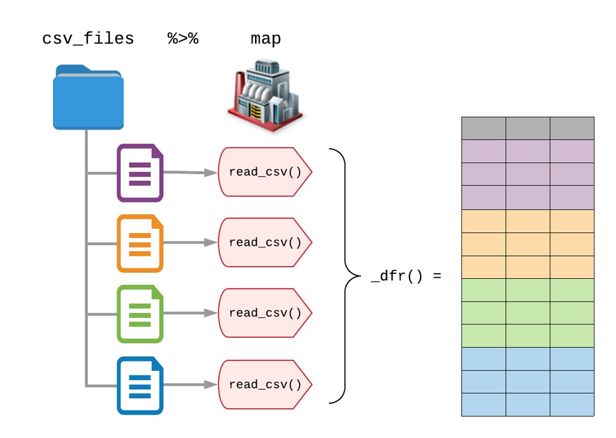

디렉토리의 모든 파일을 읽으려면 `purrr::map()`을 사용하여 `read_csv()`를 파일 목록에 매핑(**map**)합니다. 그러나 각 list() 내의 요소가 tibble(또는 data.frame)이 될 것이고 각 데이터 프레임이 동일한 열을 가짐을 알고 있으니, purrr의 타입 지정 함수인 `purrr::map_dfr()`를 사용하여 가져온 CSV 파일 각각을 포함하는 단일 data.frame으로 가져와 보겠습니다. `*_dfr()`가 추가로 달려있는 함수들은 각 요소를 행결합(row-binding)하여 data.frame을 반환하도록 합니다.(이것은 `map() %>% bind_rows()` 를 호출하는 것과 같습니다.)

```r
csv_files %>%
  map_dfr(read_csv)
```

```
# A tibble: 12,278 x 6
   Month_Year Hospital_Name Hospital_ID Hospital_Depart… ReferralType
   <chr>      <chr>               <dbl> <chr>            <chr>
 1 Aug-15     AMNCH                1049 Paediatric ENT   General Ref…
 2 Aug-15     AMNCH                1049 Paediatric Gast… General Ref…
 3 Aug-15     AMNCH                1049 Paediatric Gene… General Ref…
 4 Aug-15     Bantry Gener…         704 Gastroenterology General Ref…
 5 Aug-15     Bantry Gener…         704 General Medicine General Ref…
 6 Aug-15     Bantry Gener…         704 General Surgery  General Ref…
 7 Aug-15     Bantry Gener…         704 Medicine for th… General Ref…
 8 Aug-15     Bantry Gener…         704 Outreach Dermat… General Ref…
 9 Aug-15     Bantry Gener…         704 Outreach Orthop… General Ref…
10 Aug-15     Bantry Gener…         704 Outreach Surgic… General Ref…
# … with 12,268 more rows, and 1 more variable: TotalReferrals <dbl>
```

#### 전체 파일을 불러올 때 추가 설정하기

`Month_Year` 컬럼이 날짜/시간 자료형이 아니라 글자로 불러와져 있는 것을 알 수 있습니다. `read_csv()` 함수의 인자를 `read_csv()`함수에서 사용하는 것 처럼 `map_dfr()` 안에서 사용할 수 있습니다.(역자 주: `read_csv()` 함수에서 컬럼의 자료형을 지정하는 형태의 인자를 뜻합니다. 개인적으로는 다음 방법인 불러온 후 수정하는 방식을 선호합니다.)

```r
csv_files %>%
  map_dfr(read_csv, col_types = cols("Month_Year" = col_date(format = "%b-%y")))
```

```
# A tibble: 12,278 x 6
   Month_Year Hospital_Name Hospital_ID Hospital_Depart… ReferralType
   <date>     <chr>               <dbl> <chr>            <chr>
 1 2015-08-01 AMNCH                1049 Paediatric ENT   General Ref…
 2 2015-08-01 AMNCH                1049 Paediatric Gast… General Ref…
 3 2015-08-01 AMNCH                1049 Paediatric Gene… General Ref…
 4 2015-08-01 Bantry Gener…         704 Gastroenterology General Ref…
 5 2015-08-01 Bantry Gener…         704 General Medicine General Ref…
 6 2015-08-01 Bantry Gener…         704 General Surgery  General Ref…
 7 2015-08-01 Bantry Gener…         704 Medicine for th… General Ref…
 8 2015-08-01 Bantry Gener…         704 Outreach Dermat… General Ref…
 9 2015-08-01 Bantry Gener…         704 Outreach Orthop… General Ref…
10 2015-08-01 Bantry Gener…         704 Outreach Surgic… General Ref…
# … with 12,268 more rows, and 1 more variable: TotalReferrals <dbl>
```

#### 날짜 자료형 문제를 불러오기 *이후에* 처리하기

이것을 고치는 가장 쉬운 방법은, 글자 자료형 그대로 불러온 후에 `lubridate` 패키지의 날짜 변환 함수를 사용하는 것입니다. readr의 col_date() 함수는 하나의 포멧만 허용하기 때문입니다.

```r
library(lubridate)

csv_files %>%
  map_dfr(read_csv) %>%
  mutate(Month_Year = myd(Month_Year, truncated = 1))
```

```
# A tibble: 12,278 x 6
   Month_Year Hospital_Name Hospital_ID Hospital_Depart… ReferralType
   <date>     <chr>               <dbl> <chr>            <chr>
 1 2015-08-01 AMNCH                1049 Paediatric ENT   General Ref…
 2 2015-08-01 AMNCH                1049 Paediatric Gast… General Ref…
 3 2015-08-01 AMNCH                1049 Paediatric Gene… General Ref…
 4 2015-08-01 Bantry Gener…         704 Gastroenterology General Ref…
 5 2015-08-01 Bantry Gener…         704 General Medicine General Ref…
 6 2015-08-01 Bantry Gener…         704 General Surgery  General Ref…
 7 2015-08-01 Bantry Gener…         704 Medicine for th… General Ref…
 8 2015-08-01 Bantry Gener…         704 Outreach Dermat… General Ref…
 9 2015-08-01 Bantry Gener…         704 Outreach Orthop… General Ref…
10 2015-08-01 Bantry Gener…         704 Outreach Surgic… General Ref…
# … with 12,268 more rows, and 1 more variable: TotalReferrals <dbl>
```

#### 파일명 컬럼 추가하기

데이터를 사용하다보면 보고 있는 값이 어느 파일에서 나온 것인지 확인하고 싶을 떄가 있습니다(역자주: 지금의 구조에서는 년도로 구분되어 있기 때문에 날짜 컬럼을 확인하면 됩니다만, `.id` 인자는 `bind_rows()` 함수에서도 유용하게 사용하는 것이니 알아두면 좋습니다.). `map_dfr()` 함수의 `.id` 인자를 지정하고 싶은 컬럼명(지금은 `source`)을 작성하는 것으로 사용하면, `source` 컬럼이 해당 파일이름이 추가되어 최종 데이터셋에 반영됩니다.

```r
csv_files %>%
  map_dfr(read_csv, .id = "source") %>%
  mutate(Month_Year = myd(Month_Year, truncated = 1))
```

```
# A tibble: 12,278 x 7
   source Month_Year Hospital_Name Hospital_ID Hospital_Depart…
   <chr>  <date>     <chr>               <dbl> <chr>
 1 ie-ge… 2015-08-01 AMNCH                1049 Paediatric ENT
 2 ie-ge… 2015-08-01 AMNCH                1049 Paediatric Gast…
 3 ie-ge… 2015-08-01 AMNCH                1049 Paediatric Gene…
 4 ie-ge… 2015-08-01 Bantry Gener…         704 Gastroenterology
 5 ie-ge… 2015-08-01 Bantry Gener…         704 General Medicine
 6 ie-ge… 2015-08-01 Bantry Gener…         704 General Surgery
 7 ie-ge… 2015-08-01 Bantry Gener…         704 Medicine for th…
 8 ie-ge… 2015-08-01 Bantry Gener…         704 Outreach Dermat…
 9 ie-ge… 2015-08-01 Bantry Gener…         704 Outreach Orthop…
10 ie-ge… 2015-08-01 Bantry Gener…         704 Outreach Surgic…
# … with 12,268 more rows, and 2 more variables: ReferralType <chr>,
#   TotalReferrals <dbl>
```

### 마무리

본 포스트는 `fs` 패키지, `purrr` 패키지, `readr` 패키지를 활용해서 폴더 내의 파일들 리스트를 가져와서 `tidyverse` 패키지의 도구들도 분석하기 좋은 상태인 하나의 data.frame으로 불러오는 작은 예제를 제공한다.

한번에 동작하는 코드 전체는 아래와 같다.

```r
data_dir %>%
  dir_ls(regexp = "\\.csv$") %>%
  map_dfr(read_csv, .id = "source") %>%
  mutate(Month_Year = myd(Month_Year, truncated = 1))
```

`dir_ls()` 함수로 data_dir 폴더내의 파일 리스트를 가져와서, `read_csv()` 함수를 `map_dfr()` 함수와 함께 리스트의 파일들을 한번에 불러옵니다. `.id` 인자로 `source` 컬럼을 추가하여 어느 파일에서 나온 데이터인지 최종 데이터셋에서 확인할 수 있습니다. 이제 `dplyr` 패키지로 데이터를 처리 할 준비가 되었습니다.

코드는 조금만 바꿔서 SAS 파일이나 Excel 파일 같은 다른 파일 형식을 위한 형태로 고칠 수 있습니다. `read_csv()` 함수를 `haven::read_sas()`나 `readxl::read_xlsx()`로 바꾸고 `regexp` 인자를 해당 확장자명으로 고치는 것입니다.

In future posts, we’ll also look at other ways we merge a folder of data files besides “stapling” them together row-wise with map_dfr(). (역자주: `stapling`이 어떤 의미인지 이해하지 못해서 마지막 문장은 원문으로 두었습니다.)

### 역자 의견

[purrr](https://purrr.tidyverse.org/) 패키지는 저도 아직 이해를 잘 못하고 있지만, 제대로 쓰기를 기대하는 패키지 중 하나 입니다. R이 for문의 성능이 떨어지기 때문에 apply계열 함수를 잘 사용해야 한다는 이야기들을 하지만, 모던 R 프로그래밍에서는 [purrr](https://purrr.tidyverse.org/) 패키지의 `map_*()` 계열 함수를 잘 사용해야 하는 것 같습니다.

[KRUG](https://www.facebook.com/groups/KoreaRUsers/)에서 언뜻 `map()`으로 어떤 처리코드보다도 빠르게 동작하는 코드를 공유해주신 분을 기억합니다. 덕분에 관심만 두고 있었는데, 빨리 더 살펴봐야 겠네요.

글의 내용과는 무관하게 본 포스트는 총 4줄의 코드를 설명하고 있습니다. 반성을 많이 하게 되네요.